# Descripte analysis

Lucas Avezum

June 17, 2019

## Data

In this report I briefly describe the data collected so far and provide some descriptive analysis of two measures of capital savings.

Figure 1 plots the PD distribution collected by bank.

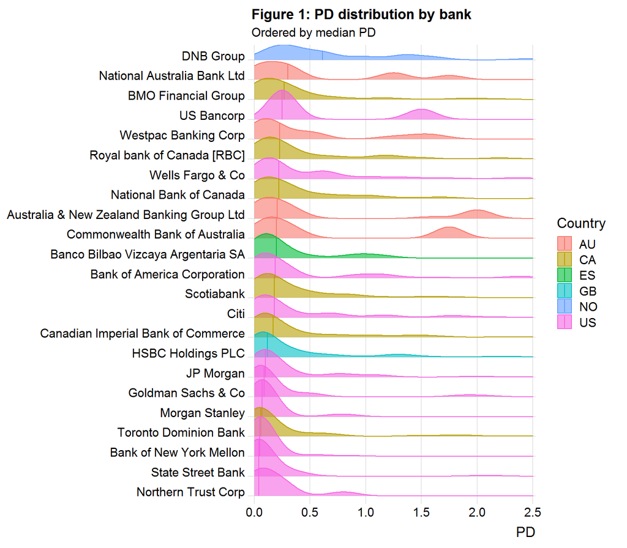

## Basel formulas and capital savings

$K=\sum_{i}EAD_i\times LGD_i\times\bigg[\Phi\bigg(\frac{\Phi^{-1}(PD_i)+\sqrt{\rho_i}\Phi^{-1}(0.999)}{\sqrt{1-\rho_i}}\bigg)-PD_i\bigg]$

For wholesale portfolio: $K_{\text{wholesale}}=K\times \frac{1+(M-2.5)b(PD_i))}{1-1.5b(PD_i)}$ with$\rho_i = 0.12\times\bigg(\frac{1-e^{-50\times PD_i}}{1-e^{-50}}+0.24\times\bigg(1-\frac{1-e^{-50\times PD_i}}{1-e^{-50}}\bigg)\bigg)$

and $b(PD_i)=(0.11852-0.05478\times log(PD_i))^2$

For retail portfolios the formula is equal to $K$ with different formulas for the correlation coefficient:

Real estate: $\rho_{i}=0.15$

Qualifying revolving: $\rho_{i}=0.04$

Other retail: $0.03\times\bigg(\frac{1-e^{-35\times PD_i}}{1-e^{-35}}+0.16\times\bigg(1-\frac{1-e^{-35\times PD_i}}{1-e^{-35}}\bigg)\bigg)$

Using these formulas I computed two measures of capital requirement: $K_{distribution}$ using the distribution of $PD_i$ (as it is required by the Basel accords), and $K_{average}$ using $\widetilde{PD}=\sum_iEAD_iLGD_iPD_i/\sum_iEAD_iLGD_i$. The percentage change $K_{distribution}/K_{average}-1$ is called capital savings and is a measure of the amount of capital saved due to the concavity in the formula for $K$.

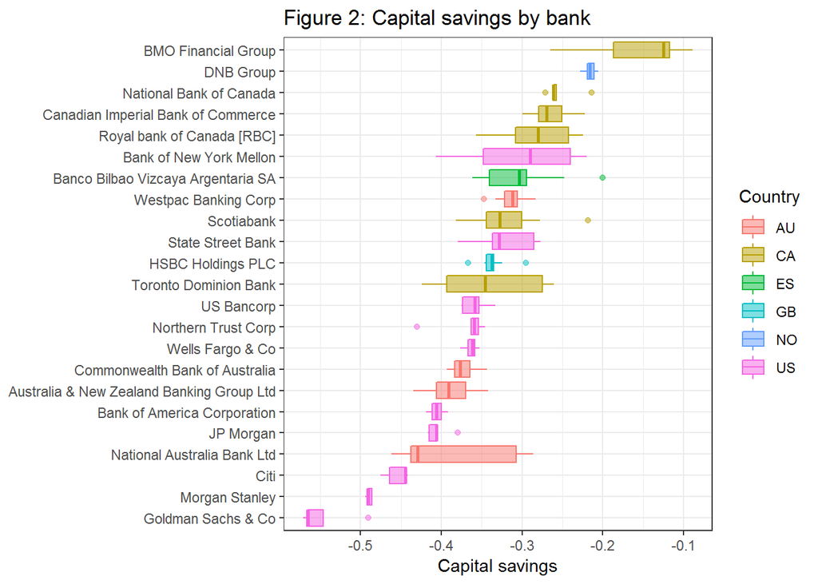

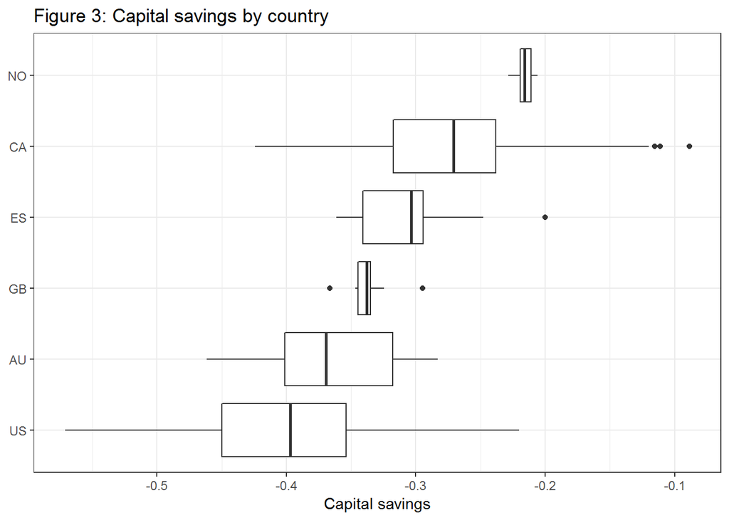

[figure not shown]

## Basel formulas and Gini coefficient

As a second measure of the $PD$ distribution dispersion I compute Gini coefficients. Figure 4 shows the Lorenz curve of the $PD$ distributions by country. Figure 5 shows the Lorenz curve of the $PD$ distributions by year. Figure 6 shows the Lorenz curve of the $PD$ distributions by Bank (names omitted for visibility). Finally Figure 7 plots the measure of capital savings and the Gini coefficients.

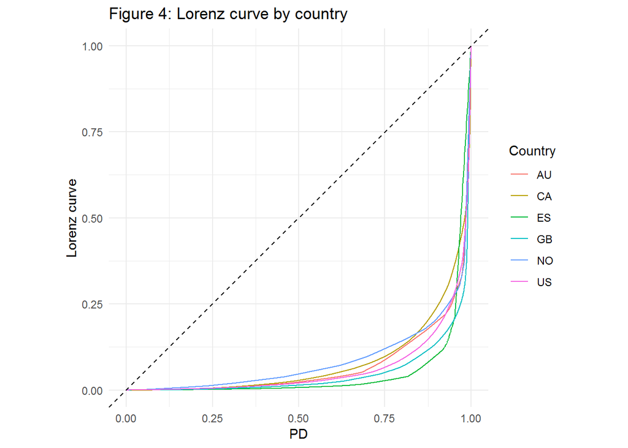

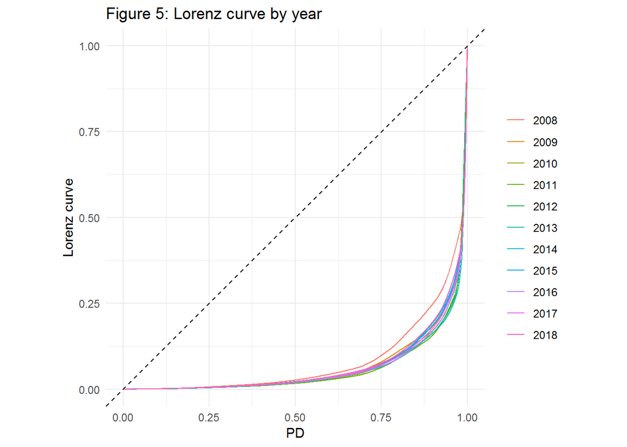

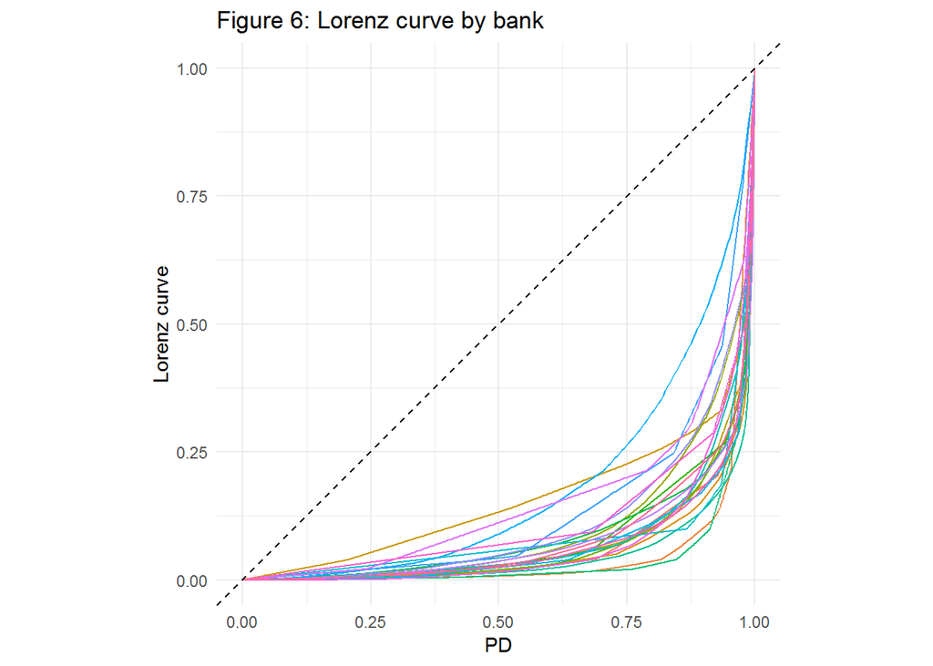

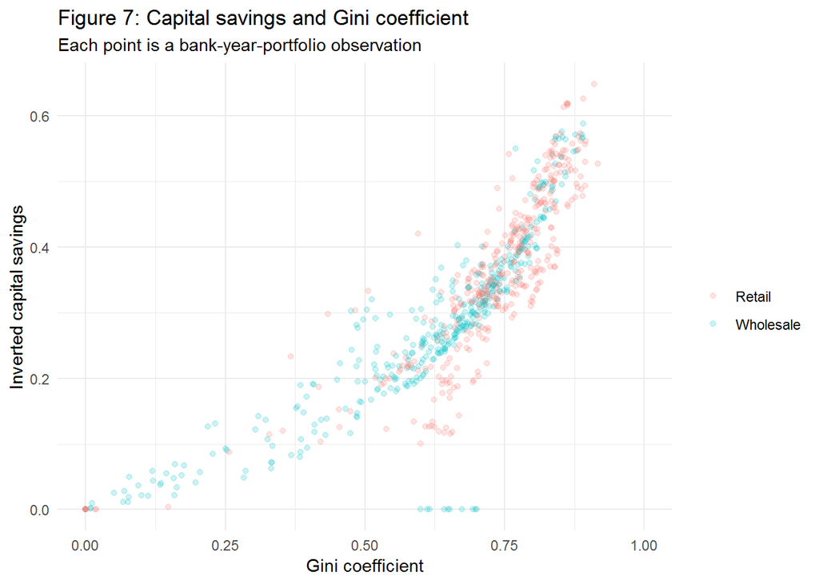